# Grupo 6

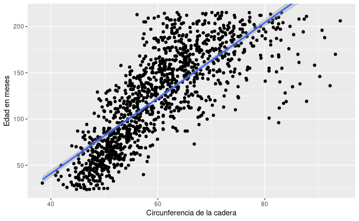

```r
datos %>% filter(NATURAL.WAIST.CIRCUMFERENCE > 0) %>% mutate(NATURAL.WAIST.CIRCUMFERENCE = NATURAL.WAIST.CIRCUMFERENCE/10)-> datos_circunferenciacadera
ggplot(datos_circunferenciacadera, aes(x = NATURAL.WAIST.CIRCUMFERENCE, y = AGE.IN.MONTHS)) + geom_point() + geom_jitter() + labs(x = 'Circunferencia de la cadera', y = 'Edad en meses')+ geom_smooth(method = lm) + coord_cartesian(y = c(24,215))
```

```r
#
modelo_circunferenciacadera <- lm(AGE.IN.MONTHS~NATURAL.WAIST.CIRCUMFERENCE, datos_circunferenciacadera)
#
modelo_circunferenciacadera_S <- lm(AGE.IN.MONTHS~(NATURAL.WAIST.CIRCUMFERENCE+SEX), datos_circunferenciacadera)
#
modelo_circunferenciacadera_P <- lm(AGE.IN.MONTHS~(NATURAL.WAIST.CIRCUMFERENCE+WEIGHT), datos_circunferenciacadera)
#
modelo_circunferenciacadera_ES <- lm(STATURE~NATURAL.WAIST.CIRCUMFERENCE, datos_circunferenciacadera)
#
modelo_circunferenciacadera_W <- lm(WEIGHT~NATURAL.WAIST.CIRCUMFERENCE, datos_circunferenciacadera)
#
summary(modelo_circunferenciacadera)
```

```
Call:
lm(formula = AGE.IN.MONTHS ~ NATURAL.WAIST.CIRCUMFERENCE, data = datos_circunferenciacadera)

Residuals:
     Min       1Q   Median       3Q      Max
-118.635  -22.093   -2.166   21.354  106.305

Coefficients:
                              Estimate Std. Error t value Pr(>|t|)
(Intercept)                 -121.81285    5.66350  -21.51   <2e-16 ***
NATURAL.WAIST.CIRCUMFERENCE    4.07322    0.09309   43.75   <2e-16 ***
---
Signif. codes:  0 ‘***’ 0.001 ‘**’ 0.01 ‘*’ 0.05 ‘.’ 0.1 ‘ ’ 1

Residual standard error: 32.07 on 1227 degrees of freedom
Multiple R-squared:  0.6094,    Adjusted R-squared:  0.6091
F-statistic:  1914 on 1 and 1227 DF,  p-value: < 2.2e-16
```

```r
# Tiene un r cuadrado de 0.60, hay mejores variables predictoras
summary(modelo_circunferenciacadera_S)
```

```
Call:
lm(formula = AGE.IN.MONTHS ~ (NATURAL.WAIST.CIRCUMFERENCE + SEX),
    data = datos_circunferenciacadera)

Residuals:
     Min       1Q   Median       3Q      Max
-129.185  -21.053   -0.438   22.101   99.137

Coefficients:
                              Estimate Std. Error t value Pr(>|t|)
(Intercept)                 -151.32102    6.55269 -23.093   <2e-16 ***
NATURAL.WAIST.CIRCUMFERENCE    4.19176    0.09172  45.703   <2e-16 ***
SEX                           15.01301    1.80275   8.328   <2e-16 ***
---
Signif. codes:  0 ‘***’ 0.001 ‘**’ 0.01 ‘*’ 0.05 ‘.’ 0.1 ‘ ’ 1

Residual standard error: 31.21 on 1226 degrees of freedom
Multiple R-squared:  0.6303,    Adjusted R-squared:  0.6297
F-statistic:  1045 on 2 and 1226 DF,  p-value: < 2.2e-16
```

```r
# Mejora un 0.03, no es mucho
summary(modelo_circunferenciacadera_P)
```

```
Call:
lm(formula = AGE.IN.MONTHS ~ (NATURAL.WAIST.CIRCUMFERENCE + WEIGHT),
    data = datos_circunferenciacadera)

Residuals:
    Min      1Q  Median      3Q     Max
-88.443 -14.651  -1.132  14.603  71.220

Coefficients:
                            Estimate Std. Error t value Pr(>|t|)
(Intercept)                  99.9050     6.9393   14.40   <2e-16 ***
NATURAL.WAIST.CIRCUMFERENCE  -1.8519     0.1670  -11.09   <2e-16 ***
WEIGHT                        3.6911     0.0964   38.29   <2e-16 ***
---
Signif. codes:  0 ‘***’ 0.001 ‘**’ 0.01 ‘*’ 0.05 ‘.’ 0.1 ‘ ’ 1

Residual standard error: 21.65 on 1226 degrees of freedom
Multiple R-squared:  0.8221,    Adjusted R-squared:  0.8218
F-statistic:  2833 on 2 and 1226 DF,  p-value: < 2.2e-16
```

```r
# Mejora bastante, no es de extrañar
summary(modelo_circunferenciacadera_ES)
```

```
Call:
lm(formula = STATURE ~ NATURAL.WAIST.CIRCUMFERENCE, data = datos_circunferenciacadera)

Residuals:
    Min      1Q  Median      3Q     Max
-56.603  -8.860   0.492   9.333  41.165

Coefficients:
                            Estimate Std. Error t value Pr(>|t|)
(Intercept)                 12.89415    2.34776   5.492 4.82e-08 ***
NATURAL.WAIST.CIRCUMFERENCE  2.07869    0.03859  53.864  < 2e-16 ***
---
Signif. codes:  0 ‘***’ 0.001 ‘**’ 0.01 ‘*’ 0.05 ‘.’ 0.1 ‘ ’ 1

Residual standard error: 13.29 on 1227 degrees of freedom
Multiple R-squared:  0.7028,    Adjusted R-squared:  0.7025
F-statistic:  2901 on 1 and 1227 DF,  p-value: < 2.2e-16
```

```r
# No hay tanta relacion como en otros casos, lo cual se veia reflejado en el grafico. No llega a 0,90
summary(modelo_circunferenciacadera_W)
```

```
Call:
lm(formula = WEIGHT ~ NATURAL.WAIST.CIRCUMFERENCE, data = datos_circunferenciacadera)

Residuals:
     Min       1Q   Median       3Q      Max
-28.5866  -4.0340  -0.7629   3.9871  21.3897

Coefficients:
                             Estimate Std. Error t value Pr(>|t|)
(Intercept)                 -60.06872    1.13229  -53.05   <2e-16 ***
NATURAL.WAIST.CIRCUMFERENCE   1.60526    0.01861   86.25   <2e-16 ***
---
Signif. codes:  0 ‘***’ 0.001 ‘**’ 0.01 ‘*’ 0.05 ‘.’ 0.1 ‘ ’ 1

Residual standard error: 6.412 on 1227 degrees of freedom
Multiple R-squared:  0.8584,    Adjusted R-squared:  0.8583
F-statistic:  7439 on 1 and 1227 DF,  p-value: < 2.2e-16
```

```r
# Hay más relacion con el peso que con la altura.
# Este podria ser, porque esta mas relacionado con el peso que con la altura.
error_circunferenciacadera <- PMAE(datos_circunferenciacadera$AGE.IN.MONTHS, as.vector(predict(modelo_circunferenciacadera)))
error_circunferenciacadera
```

```
[1] 0.208
```

```r
cant_observaciones <- floor(0.2*nrow(datos_caderasentado))
cruzada_circunferenciacadera <- crossval(datos_circunferenciacadera, formula('AGE.IN.MONTHS~NATURAL.WAIST.CIRCUMFERENCE'), cant_observaciones, PMAE)
cruzada_circunferenciacadera
```

```
$Errores
 [1] 0.213 0.213 0.202 0.210 0.209 0.209 0.211 0.209 0.209 0.214

$`Promedio errores`
[1] 0.21

$`Varianza errores`
[1] 1.143333e-05

$Formula
AGE.IN.MONTHS ~ NATURAL.WAIST.CIRCUMFERENCE

$`Modelo ajustado`

Call:
lm(formula = modelo, data = datos)

Coefficients:
                (Intercept)  NATURAL.WAIST.CIRCUMFERENCE
                   -121.813                        4.073
```

#### De este modelo vamos a hablar que esta mas relacionado con el peso que con la altura. Error de ajuste: 0.20. Error de prediccion: 0.21

### Veamos el centro de gravedad

[figure not shown]

```r
datos %>% filter(STANDING.CENTER.OF.GRAVITY > 0) -> datos_gravedad
ggplot(datos_gravedad, aes(x = STANDING.CENTER.OF.GRAVITY, y = STATURE)) + geom_point() + geom_jitter() + labs(x = 'Centro de gravedad',y = 'Edad en meses')+ geom_smooth(method = lm)
```

```r
# De aca lo que vemos es que, en el fondo, el centro de gravedad y la altura estan midiendo lo mismo.
# Este es un muy buen grafico para mostrar al final.
```

#### Una relacion casi perfecta eso implica cierta desconfianza

### Conclusiones

#### Primer punto: lo que nosotros quisimos modelar, la edad en meses en funcion de distintas variables del cuerpo, esta mediado por el crecimiento, que afecta a todas las partes del cuerpo aunque no por igual, como pudimos ver. Sin embargo, esta relacion se hace mas debil a partir de los 125 meses.

#### Segundo: creemos que es el crecimiento la variable que explica la prediccion con la altura.

#### Tercer punto: el dataset tenia muchos datos faltantes.

#### Cuarto: nos resulta raro que el sexo no haya sido una variable relevante, sobre todo con la altura.

#### Quinto: el peso no es una variable tan relevante a la hora de predecir la edad en comparacion con la altura. Probablemente haya mas variaciones individuales